# analysis of Ontario COVID19 data

Ben Bolker, Michael Li, Jonathan Dushoff, David Earn (McMaster University)

14 Apr 2020

## Getting data

Reading data from Michael Li’s [curated Canadian COVID data repository](https://wzmli.github.io/COVID19-Canada) harvested from official sources such as [this](https://www.ontario.ca/page/2019-novel-coronavirus#section-0) and [hospitalization cumulative counts](http://wzmli.github.io/COVID19-Canada/PHO.csv) gathered from [Public Health Ontario Epidemiological Summary](https://files.ontario.ca/moh-covid-19-report-en-2020-04-07.pdf). (Latest data in this example are from 2020-04-13.)

## Basic visualization

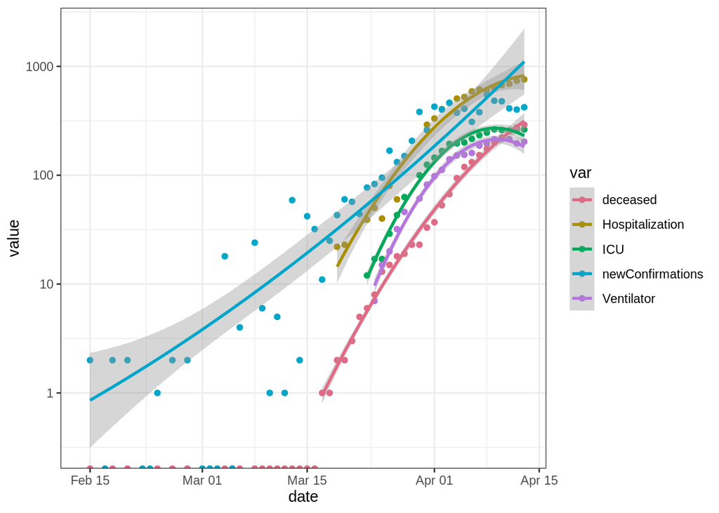

- Natural for ICU and Ventilator to be parallel (no real lags here)
- recent nonlinearity/flattening in cases is too recent/sharp to affect the estimated slope much
- Weird that the ICU/vent curves are flattening before the other two: not apparently a capacity issue, maybe something about reporting (e.g. see [here](https://www.ontario.ca/page/2019-novel-coronavirus#7))?

Picture is cleaner (and flattening is more apparent) if we focus on more recent data.

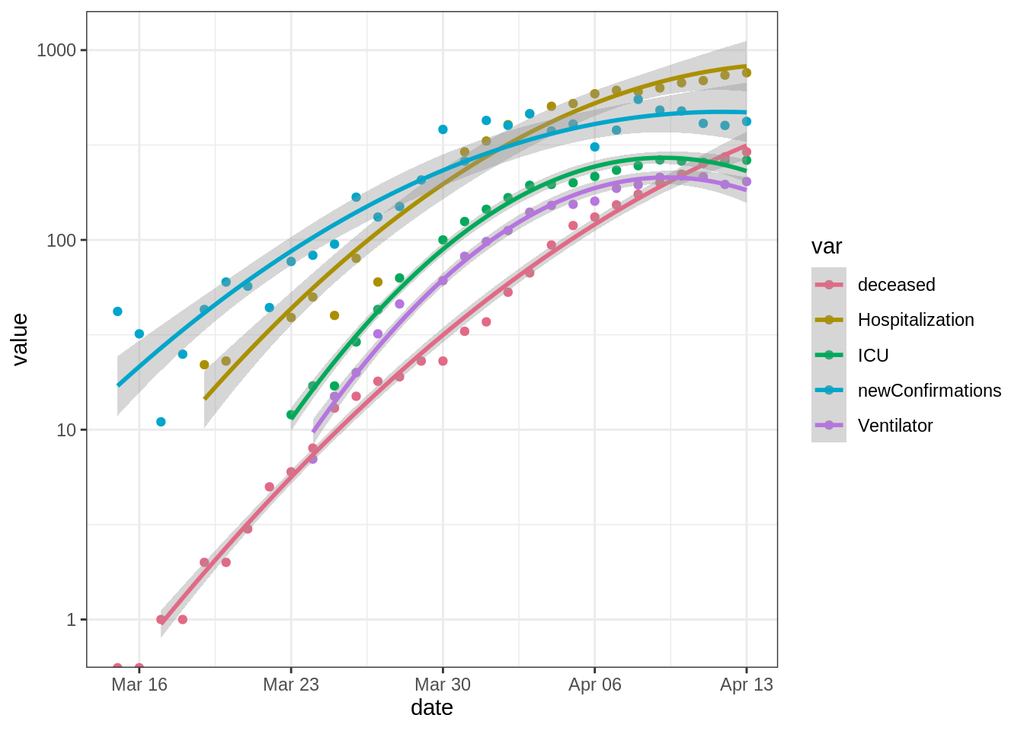

We want to find the first *useful/meaningful* day for each variable and adjust the different time series to their respective meaningful day.

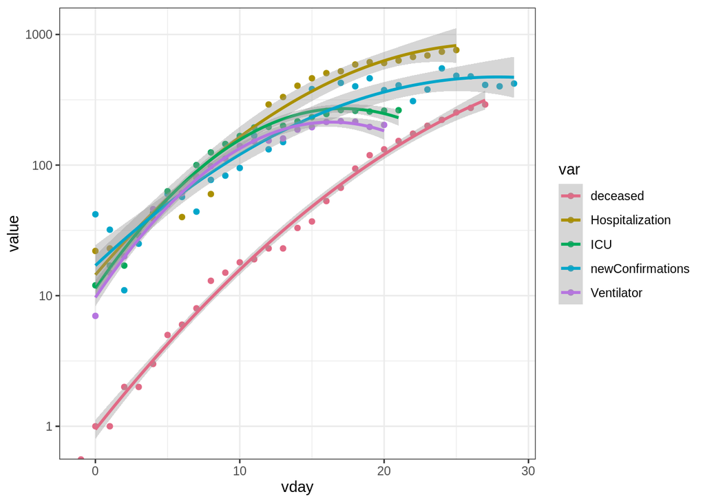